# Виконала: Германчук Аліна КМ-93

# Лабораторна робота №1:

# «Розробка програмного забезпечення для реалізації двошарового персептрону з сигмоїдальною функцією активації» з кредитного модуля «Методи глибинного навчання»

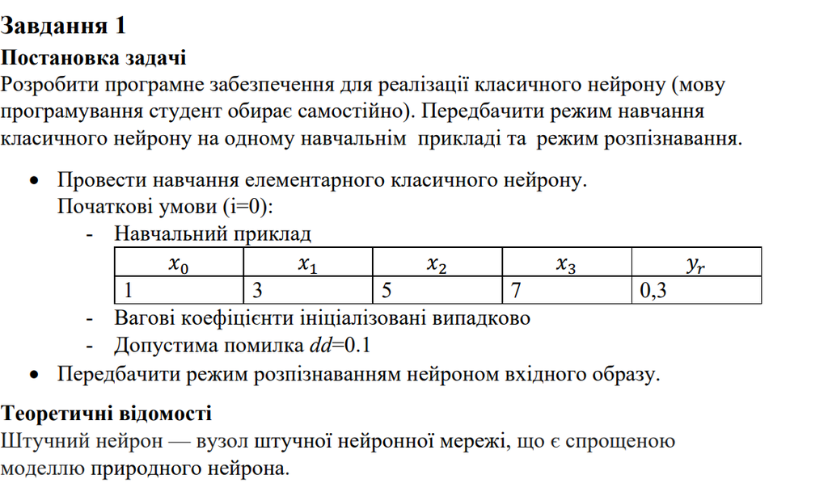

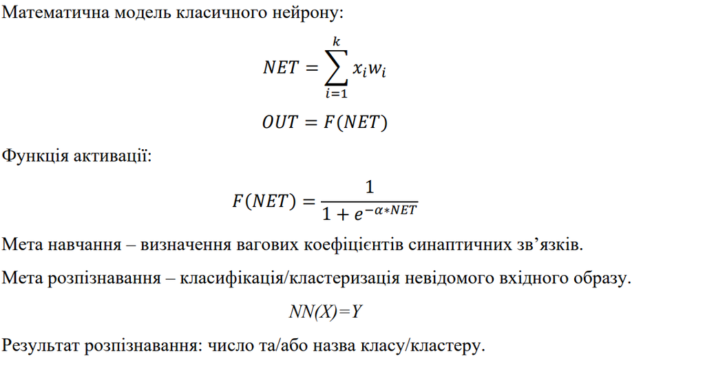

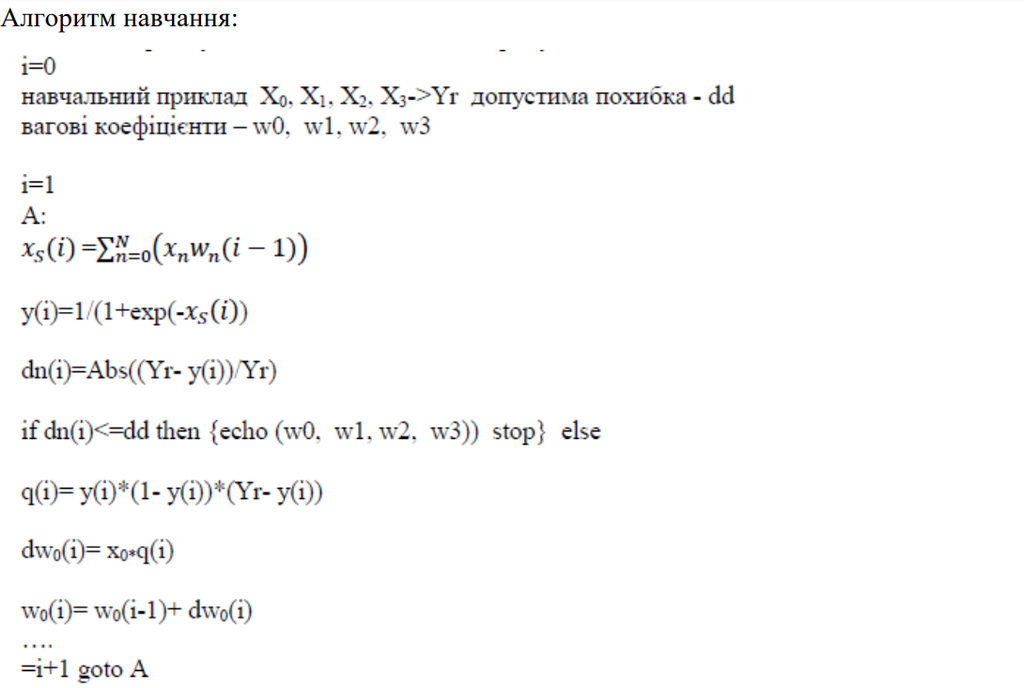

# Реалізація на Python

Імпортуємо необхідні бібліотеки

```python
import numpy as np
import matplotlib.pyplot as plt
```

Задані дані - вхідний масив х, вихідне число y, похибка dd. Ваги w - випадково згенеровані числа

```python
x = np.array([1, 3, 5, 7])
w = np.random.rand(4)
y = 0.3
dd = 0.1
```

Пишемо функцію sum_of_weigths, яка виконує роль суматора та функцію activation, яка активує вхід, вокористовуючи сигмоїдальну функцію

```python
def sum_of_weigths(X, w):
    return X.dot(w)

def activation(x):
    a = 1 / (1 + np.exp(-x))
    return a
```

Пишемо функцію train, що повертає словник зі значеннями y та похибки dn на кожній ітерації; пишемо функцію ploting для візуалізації словника та функцію visual для відображення даних

```python
dict_of_w = {}
res_dict = {}

def train(w, real = y, i = 0):
    global dict_of, list_of
    pred = activation(sum_of_weigths(x, w))
    delta = x * pred * (1 - pred) * (real - pred) # розрахунок дельти вагів
    new_w = w + delta # оновлення вагів

    dict_of_w[i] = new_w # внесення нових вагів в dict, де ключ - номер ітерації
    res_dict[pred] = abs((real - pred)/real) # розрахунок похибки і внесення її в словник

    if abs((real - pred)/real) > dd: #перевірка виконання умови
        train(new_w, i = i+1) # рекурсійно викликаємо функцію, яка вже приймає оновлені ваги

    else:
        return res_dict

def ploting(result_dict, title):
    fig, ax = plt.subplots()
    fig.suptitle(title)
    ax.set_xlabel('Номер ітерації')
    ax.set_ylabel('Значення')
    ax.plot(result_dict.items())
    ax.legend(['Результат(y)', 'Похибка(dn)'])

def visual(dict):
    list = [i for i in enumerate(dict.items())]
    for i in list[:5]: print('Номер ітерації: %d \nРезультат(y), похибка(dn) \n%s' % i)
    print('\n...\n')
    for i in list[-5:]: print('Номер ітерації: %d \nРезультат(y), похибка(dn) \n%s' % i)
    return None
```

Проміжні результати (перші та останні 5 ітерацій)

```python
train(w)
visual(res_dict)
```

```
Номер ітерації: 0
Результат(y), похибка(dn)
(0.9446449924655513, 2.148816641551838)
Номер ітерації: 1
Результат(y), похибка(dn)
(0.5013710470181082, 0.6712368233936941)
Номер ітерації: 2
Результат(y), похибка(dn)
(0.01443903065631382, 0.9518698978122874)
Номер ітерації: 3
Результат(y), похибка(dn)
(0.020194848557074516, 0.9326838381430849)
Номер ітерації: 4
Результат(y), похибка(dn)
(0.03177270117935712, 0.8940909960688097)

...

Номер ітерації: 32
Результат(y), похибка(dn)
(0.01654250055045212, 0.9448583314984929)
Номер ітерації: 33
Результат(y), похибка(dn)
(0.024179503520085133, 0.9194016549330496)
Номер ітерації: 34
Результат(y), похибка(dn)
(0.04104772128392108, 0.8631742623869297)
Номер ітерації: 35
Результат(y), похибка(dn)
(0.09154733913488675, 0.6948422028837108)
Номер ітерації: 36
Результат(y), похибка(dn)
(0.30182117990702745, 0.006070599690091531)
```

Візуалізація результатів:

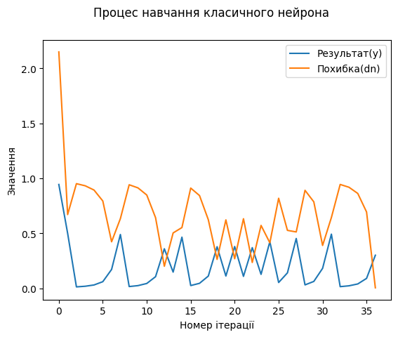

```python
ploting(res_dict, 'Процес навчання класичного нейрона')
```

# Кінцева відповідь

```python
print('Результат навчання нейрона: \nY = %s \nw = %s '
      % (list(res_dict.keys())[-1], list(dict_of_w.values())[-1]))
```

```
Результат навчання нейрона:
Y = 0.30182117990702745
w = [ 0.3702123   0.02704    -0.16241572 -0.07287583]
```

# Перевіримо роботу програми на тестувальних даних

```python
x_test = np.array([2, 4, 8, 10])
```

```python
test_result = activation(sum_of_weigths(x_test, list(dict_of_w.values())[-1]))
print('При введені вхідних данних X = %s, програма видає Y = %s' % (x_test, test_result))
```

```
При введені вхідних данних X = [ 2  4  8 10], програма видає Y = 0.23514221428733256
```

# Висновок

В 1 частині лабораторної роботи я розробила програмне заберпечення для реалізації класичного нейрону. Натренерувала його на заданих вхідних данних та забезпечила режим розпізнавання.

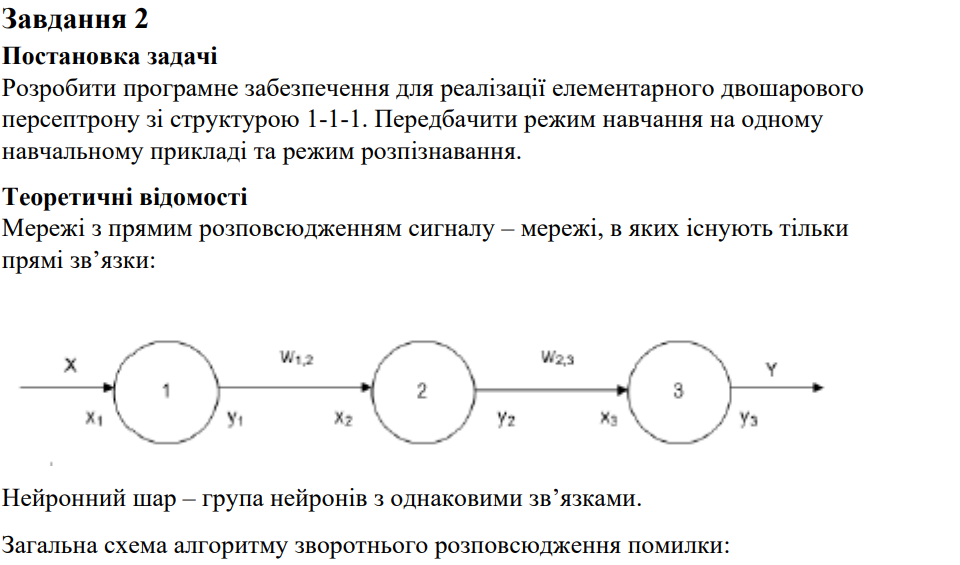

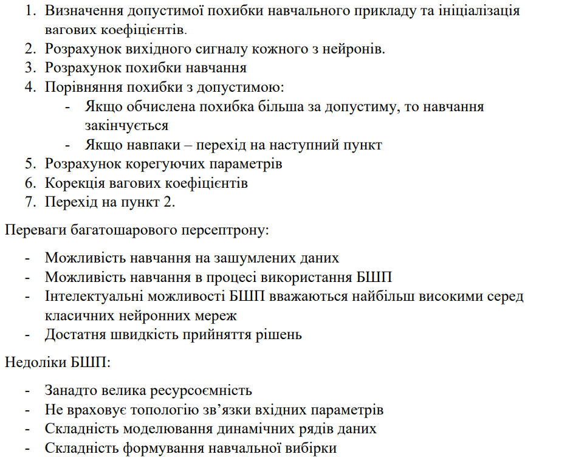

# Схема навчання елементарного двошарового персептрону зі структурою 1-1-1:

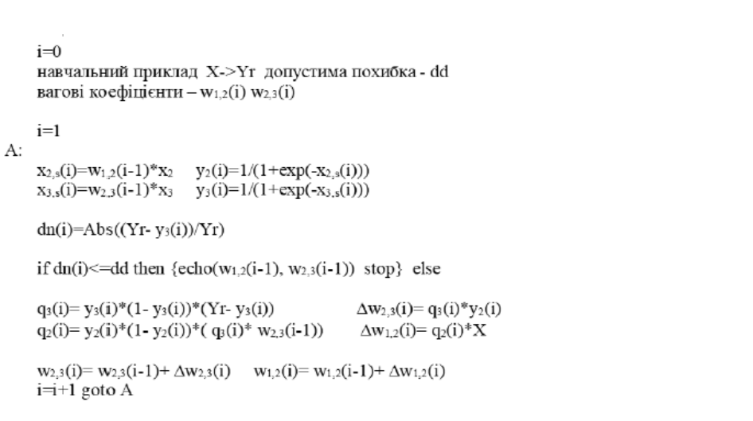

# Реалізація на Python

Введемо початкові дані: X, Y, допустиму похибку dd2 та випадково згненеровані ваги W = [w1, w2]

```python
start_x = 1
start_w = np.random.rand(2)
dd2 = 0.1
res = 0.3
```

Пишемо функцію train2, що повертає результуючі ваги та функцію test, що тестує функцію

```python
res_dict2 = {}

def train2(start_w, dd2=0.01, i=1):
    x2 = start_w[0] * start_x # підрахунок входу на 2-ий шар
    y2 = activation(x2) # активація входу на 2-ому шарі

    x3 = start_w[1] * y2 # підрахунок входу на 3-ій шар
    y3 = activation(x3) # активація входу на 3-ому шарі

    dn = abs((res - y3)/res) # підрахунок похидки
    res_dict2[y3] = dn

    if dn > dd2: # перевірка умови
        q3 = y3 * (1 - y3) * (res - y3)
        q2 = y2 * (1 - y2) * (q3 * start_w[1])

        delta_23 = q3 * y2 # розрахунок дельти для 2-го шару
        delta_12 = q2 * start_x # розрахунок дельти для 1-го шару

        w_23 = start_w[1] + delta_23 # оновлення вагів
        w_12 = start_w[0] + delta_12
        return train2(np.array([w_12, w_23]), i=i+1) # рекурсино викликаємо функцію, допоки
                                                     # умова dn > dd2 не перестане виконуватись
    else:
        return start_w

w_test2 = train2(start_w)

def test2(start):
    return (activation(activation(start * w_test2[0]) *w_test2[1]))
```

Виведемо проміжні результати

```python
train2(start_w)
visual(res_dict2)
```

```
Номер ітерації: 0
Результат(y), похибка(dn)
(0.508683780820529, 0.6956126027350967)
Номер ітерації: 1
Результат(y), похибка(dn)
(0.5045317551220713, 0.681772517073571)
Номер ітерації: 2
Результат(y), похибка(dn)
(0.5004650820547467, 0.6682169401824891)
Номер ітерації: 3
Результат(y), похибка(dn)
(0.4964804256938388, 0.6549347523127962)
Номер ітерації: 4
Результат(y), похибка(dn)
(0.49257469446943164, 0.6419156482314389)

...

Номер ітерації: 187
Результат(y), похибка(dn)
(0.3032339195112673, 0.010779731704224454)
Номер ітерації: 188
Результат(y), похибка(dn)
(0.30316158349809763, 0.010538611660325475)
Номер ітерації: 189
Результат(y), похибка(dn)
(0.3030908690405059, 0.010302896801686428)
Номер ітерації: 190
Результат(y), похибка(dn)
(0.30302173964112944, 0.010072465470431502)
Номер ітерації: 191
Результат(y), похибка(dn)
(0.3029541596299182, 0.00984719876639395)
```

Візуалізація результатів

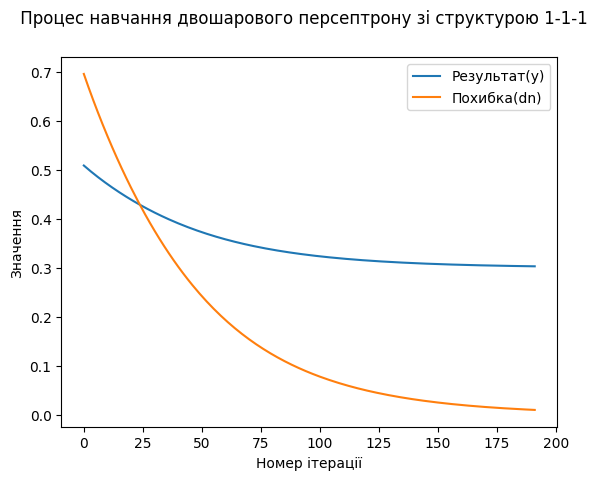

```python
ploting(res_dict2, ' Процес навчання двошарового персептрону зі структурою 1-1-1')
```

# Кінцева відповідь

```python
result2 = train2(start_w)
print('Ваги, розраховані програмою: \nW = %s' % result2)
```

```
Ваги, розраховані програмою:
W = [ 0.58596074 -1.29704331]
```

# Перевіримо роботу програми на тестувальних даних

```python
x_test_2 = np.random.uniform(3) # випадкове число від 0 до 3
print('Тестувальні дані: \nX =', x_test_2)
```

```
Тестувальні дані:
X = 1.5945994647756636
```

```python
test_result2 = test2(x_test_2)
print('При введені вхідних данних X = %s, програма видає Y = %s' % (x_test_2, test_result2))
```

```
При введені вхідних данних X = 1.5945994647756636, програма видає Y = 0.28267579954086003
```

# Висновок

В 2 частини лабораторної роботи я розробила програмне заберпечення для реалізації елементарного двошарового персептрону зі структурою 1-1-1. Натренерувала його на заданих вхідних данних та забезпечила режим розпізнавання.

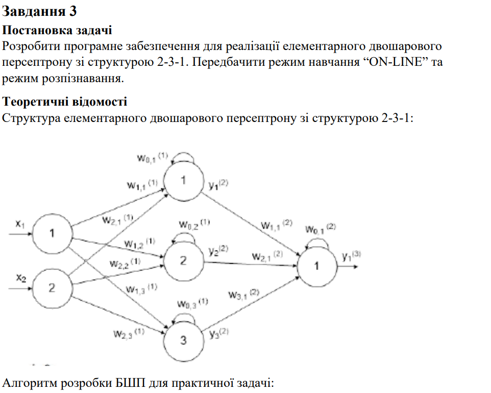

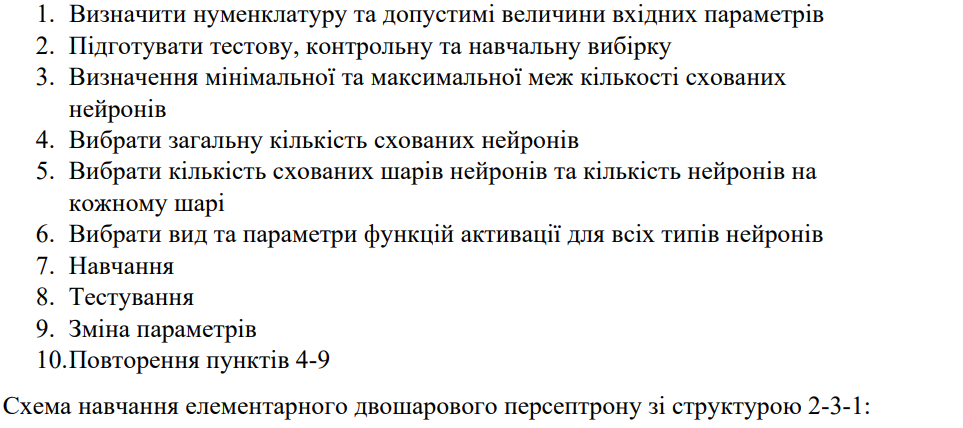

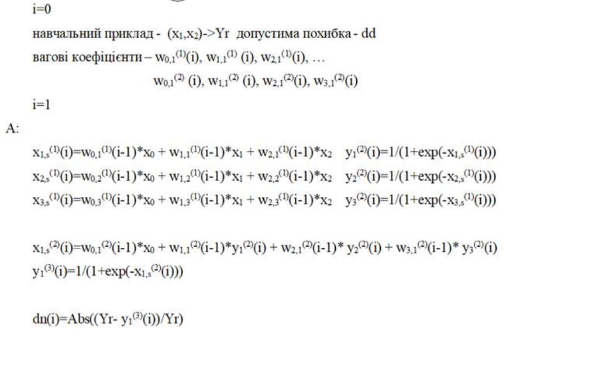

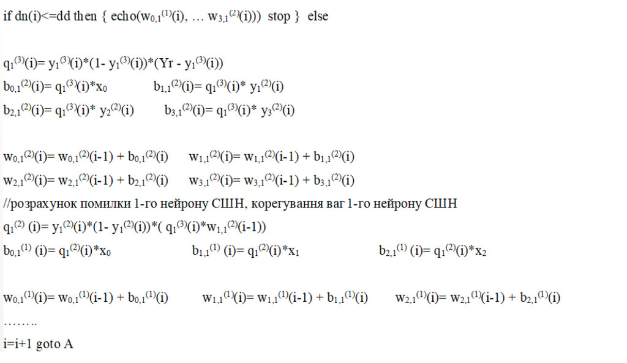

# Реалізація на Python

Введемо початкові дані: X - масив з 2-х значень, Y - сума значень в масиві, допустиму похибку dd3. Всі ваги генеруються випадково

```python
input_x = np.array([0.3, 0.2])
result = sum(input_x) # сума x1 та x2

dd3 = 0.01

middle_W = np.random.random((3, 3)) # рядки матриці описують ваги що надходять до 1, 2 та 3 елементу середнього шару
final_W = np.random.rand(4) # ваги вихідного нейрону
```

Пишемо функцію train3, що повертає, всі результуючі ваги

```python
res_dict3 = {}

def train3(middle_w, final_w, i=0):
    input_xs = np.array([1, *input_x])
    x1 = sum_of_weigths(input_xs, middle_w[0]) # розрахунок входу до 1 елементу середнього шару
    y1 = activation(x1) # розрахунок виходу з 1 елементу середнього шару

    x2 = sum_of_weigths(input_xs, middle_w[1])
    y2 = activation(x2)

    x3 = sum_of_weigths(input_xs, middle_w[2])
    y3 = activation(x3)

    ys = np.array([y1, y2, y3])

    X = final_w[0] * input_xs[0] + sum_of_weigths(final_w[1:], ys) # розрахунок входу до вихідного нейрона
    Y = activation(X) #  розрахунок виходу з вихідного нейрона

    dn = abs((result - Y)/result)
    #print('похибка dn: ', dn)
    res_dict3[Y] = dn
    if dn > dd3:
        q1_3 = Y * (1 - Y) * (result - Y) #розрахунок множника до дельти

        b_01_2 = q1_3 * input_xs[0] # розрахунок дельт
        b_11_2 = q1_3 * y1
        b_21_2 = q1_3 * y2
        b_31_2 = q1_3 * y3

        w_i1_2 = final_w + np.array([b_01_2,  b_11_2, b_21_2, b_31_2]) # оновлення вагів вихідного шару

        '''Розрахунок помилки 1-го нейрону СШН, корегування ваг 1-го не1рону СШН'''
        q1_2 = y1 * (1 - y1) * (q1_3 * final_w[1]) # розрахунок множника до дельти

        b_i1_1 = q1_2 * input_xs # розрахунок самої дельти

        w_i1_1 = middle_w[0] + b_i1_1 # оновленнят вагів для 1-го нерону СШН

        '''Аналогічні дії виконуються дня 2-x інших нейронів'''

        '''Розрахунок помилки 2-го нейрону СШН, корегування ваг 2-го не1рону СШН'''
        q2_2 = y2 * (1 - y2) * (q1_3 * final_w[2])

        b_i2_1 = q2_2 * input_xs

        w_i2_1 = middle_w[1] + b_i2_1

        '''Розрахунок помилки 3-го нейрону СШН, корегування ваг 3-го не1рону СШН'''
        q3_2 = y3 * (1 - y3) * (q1_3 * final_w[3])

        b_i3_1 = q3_2 * input_xs

        w_i3_1 = middle_w[2] + b_i3_1

        return train3(np.array([[*w_i1_1],
                                [*w_i2_1],
                                [*w_i3_1]]), w_i1_2, i = i+1)
    else:
        return middle_w, final_w

w_test3 = train3(middle_W, final_W)

def test3(data_test3):
    prop = np.array([1, *data_test3])
    sec_l1 = activation(sum_of_weigths(prop, w_test3[0][0]))
    sec_l2 = activation(sum_of_weigths(prop, w_test3[0][1]))
    sec_l3 = activation(sum_of_weigths(prop, w_test3[0][2]))

    prop_last = np.array([1, sec_l1, sec_l2, sec_l3])
    res = activation(sum_of_weigths(prop_last,  w_test3[1] ))
    return res
```

Виведемо проміжні результати

```python
visual(res_dict3)
```

```
Номер ітерації: 0
Результат(y), похибка(dn)
(0.7380527564279019, 0.4761055128558038)
Номер ітерації: 1
Результат(y), похибка(dn)
(0.7136131703206828, 0.42722634064136567)
Номер ітерації: 2
Результат(y), похибка(dn)
(0.6892704648838617, 0.37854092976772336)
Номер ітерації: 3
Результат(y), похибка(dn)
(0.6657326631046059, 0.33146532620921176)
Номер ітерації: 4
Результат(y), похибка(dn)
(0.6436104330319333, 0.28722086606386665)

...

Номер ітерації: 20
Результат(y), похибка(dn)
(0.5089117347980429, 0.017823469596085717)
Номер ітерації: 21
Результат(y), похибка(dn)
(0.5074445700901472, 0.014889140180294413)
Номер ітерації: 22
Результат(y), похибка(dn)
(0.5062187753653019, 0.012437550730603819)
Номер ітерації: 23
Результат(y), похибка(dn)
(0.5051947187760129, 0.010389437552025704)
Номер ітерації: 24
Результат(y), похибка(dn)
(0.5043392422971583, 0.008678484594316638)
```

Візуалізація результатів

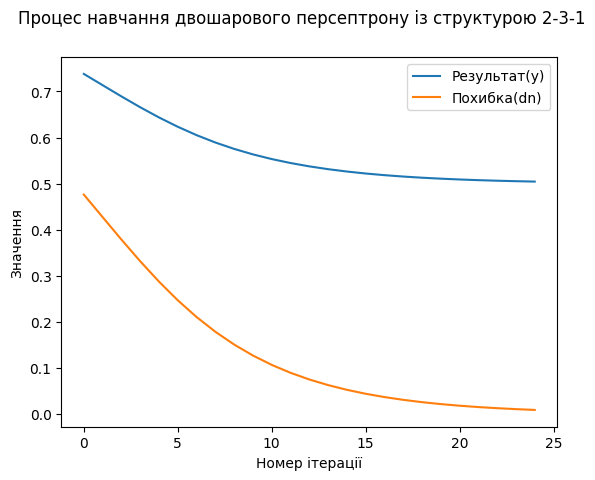

```python
ploting(res_dict3, 'Процес навчання двошарового персептрону із структурою 2-3-1')
```

Кінцева відповідь

```python
result3 = train3(middle_W, final_W)
print('Ваги, розраховані програмою: \nВаги, що надходять до середнього шару: \n%s\nВаги, що надходять до вихідного шару\n %s' % result3)
```

```
Ваги, розраховані програмою:
Ваги, що надходять до середнього шару:
[[0.3281122  0.92710682 0.55478482]
 [0.79622463 0.90002098 0.74298311]
 [0.95198675 0.39507887 0.38053331]]
Ваги, що надходять до вихідного шару
 [-0.12461404  0.46495117 -0.03782408 -0.18619656]
```

# Перевіримо роботу програми на тестувальних даних

```python
x_test_3 = np.random.rand(2)/2 # випадкові 2 числа від 0 до 0.5
print('Тестувальні дані: \nX =', x_test_3)
```

```
Тестувальні дані:
X = [0.13004676 0.34184493]
```

```python
test_result3 = test3(x_test_3)
print('При введені вхідних данних X = %s, програма видає Y = %s' % (x_test_3, test_result3))
```

```
При введені вхідних данних X = [0.13004676 0.34184493], програма видає Y = 0.5024847998661585
```

# Висновок

В 3 частині лабораторної роботи я розробила програмне заберпечення для реалізації елементарного двошарового персептрону зі структурою 2-3-1. В програмі передбаченно режим 'ON-LINE' та забезпечено режим розпізнавання.